# Final project code

Xiaoyang Li(xl2934) & Guangling Xu(gx2144) & Shenglin Liu(sl4659) & Jingyu Fu(jf3286)

2019/12/16

## Data Exploration

### Data Description

**Table 1: Summary Statistics of lawsuit Data**

|  | Female (N=106) | Male (N=155) | Total (N=261) | p value |
| --- | --- | --- | --- | --- |
| **Department** |  |  |  | < 0.001<sup>1</sup> |
| Biochemistry/Molecular Biology | 20 (18.9%) | 30 (19.4%) | 50 (19.2%) |  |
| Physiology | 20 (18.9%) | 20 (12.9%) | 40 (15.3%) |  |
| Genetics | 11 (10.4%) | 10 (6.5%) | 21 (8.0%) |  |
| Pediatrics | 20 (18.9%) | 10 (6.5%) | 30 (11.5%) |  |
| Medicine | 30 (28.3%) | 50 (32.3%) | 80 (30.7%) |  |
| Surgery | 5 (4.7%) | 35 (22.6%) | 40 (15.3%) |  |
| Missing | 0 | 0 | 0 |  |
| **Clinical Emphasis** |  |  |  | 0.197<sup>1</sup> |
| Primarily research emphasis | 46 (43.4%) | 55 (35.5%) | 101 (38.7%) |  |
| Primarily clinical emphasis | 60 (56.6%) | 100 (64.5%) | 160 (61.3%) |  |
| Missing | 0 | 0 | 0 |  |
| **Certification** |  |  |  | 0.074<sup>1</sup> |
| not certified | 36 (34.0%) | 37 (23.9%) | 73 (28.0%) |  |
| Board certified | 70 (66.0%) | 118 (76.1%) | 188 (72.0%) |  |
| Missing | 0 | 0 | 0 |  |
| **Publication Rate** |  |  |  | 0.002<sup>2</sup> |
| Mean (SD) | 5.350 (1.886) | 4.646 (1.938) | 4.932 (1.944) |  |
| Median (Q1, Q3) | 5.250 (3.725, 7.275) | 4.000 (3.100, 6.700) | 4.400 (3.200, 6.900) |  |
| Min - Max | 2.400 - 8.700 | 1.300 - 8.600 | 1.300 - 8.700 |  |
| Missing | 0 | 0 | 0 |  |
| **Experience** |  |  |  | < 0.001<sup>2</sup> |
| Mean (SD) | 7.491 (4.166) | 12.103 (6.704) | 10.230 (6.227) |  |
| Median (Q1, Q3) | 7.000 (5.000, 10.000) | 10.000 (7.000, 15.000) | 9.000 (6.000, 14.000) |  |
| Min - Max | 1.000 - 23.000 | 2.000 - 37.000 | 1.000 - 37.000 |  |
| Missing | 0 | 0 | 0 |  |
| **Rank** |  |  |  | < 0.001<sup>1</sup> |
| Assistant | 69 (65.1%) | 43 (27.7%) | 112 (42.9%) |  |
| Associate | 21 (19.8%) | 43 (27.7%) | 64 (24.5%) |  |
| Full | 16 (15.1%) | 69 (44.5%) | 85 (32.6%) |  |
| Missing | 0 | 0 | 0 |  |
| **Salary in 1994** |  |  |  | < 0.001<sup>2</sup> |
| Mean (SD) | 118871.274 (56168.006) | 177338.761 (85930.540) | 153593.345 (80469.667) |  |
| Median (Q1, Q3) | 108457.000 (75774.500, 143096.000) | 155006.000 (109687.000, 231501.500) | 133284.000 (90771.000, 200543.000) |  |
| Min - Max | 34514.000 - 308081.000 | 52582.000 - 428876.000 | 34514.000 - 428876.000 |  |
| Missing | 0 | 0 | 0 |  |
| **Salary after Increment in 1995** |  |  |  | < 0.001<sup>2</sup> |
| Mean (SD) | 130876.915 (62034.507) | 194914.090 (94902.728) | 168906.655 (88778.425) |  |
| Median (Q1, Q3) | 119135.000 (82345.250, 154170.500) | 170967.000 (119952.500, 257163.000) | 148117.000 (99972.000, 218955.000) |  |
| Min - Max | 38675.000 - 339664.000 | 58923.000 - 472589.000 | 38675.000 - 472589.000 |  |
| Missing | 0 | 0 | 0 |  |
| **ln_sal94** |  |  |  | < 0.001<sup>2</sup> |
| Mean (SD) | 11.584 (0.451) | 11.971 (0.487) | 11.814 (0.508) |  |
| Median (Q1, Q3) | 11.594 (11.235, 11.871) | 11.951 (11.605, 12.352) | 11.800 (11.416, 12.209) |  |
| Min - Max | 10.449 - 12.638 | 10.870 - 12.969 | 10.449 - 12.969 |  |
| Missing | 0 | 0 | 0 |  |
| **ln_sal95** |  |  |  | < 0.001<sup>2</sup> |
| Mean (SD) | 11.680 (0.452) | 12.064 (0.488) | 11.908 (0.510) |  |
| Median (Q1, Q3) | 11.688 (11.319, 11.946) | 12.049 (11.695, 12.457) | 11.906 (11.513, 12.297) |  |
| Min - Max | 10.563 - 12.736 | 10.984 - 13.066 | 10.563 - 13.066 |  |
| Missing | 0 | 0 | 0 |  |
| **salavg** |  |  |  | < 0.001<sup>2</sup> |
| Mean (SD) | 124874.094 (59089.620) | 186126.426 (90397.109) | 161250.000 (84608.327) |  |
| Median (Q1, Q3) | 113706.000 (79059.875, 148401.125) | 162987.000 (114612.500, 244332.250) | 141628.000 (95176.500, 210012.500) |  |
| Min - Max | 36594.500 - 323872.500 | 55752.500 - 445859.000 | 36594.500 - 445859.000 |  |
| Missing | 0 | 0 | 0 |  |
| **ln_salavg** |  |  |  | < 0.001<sup>2</sup> |
| Mean (SD) | 11.633 (0.451) | 12.018 (0.487) | 11.862 (0.509) |  |
| Median (Q1, Q3) | 11.641 (11.278, 11.908) | 12.001 (11.649, 12.406) | 11.861 (11.463, 12.255) |  |
| Min - Max | 10.508 - 12.688 | 10.929 - 13.008 | 10.508 - 13.008 |  |
| Missing | 0 | 0 | 0 |  |

1. Pearson’s Chi-squared test
2. Kruskal-Wallis rank sum test
- Values are count(percentage) for categorical variables or mean(SD), median(25% quantile, 75% quantile), min-max, count of missing values for continuous variables.* Publication Rate: Number of years between CV date and MD date;Experience: Number of years since obtaining MD; Rank: a proxy for productivity

### Data Distribution

In *Graph 1*, distributions of publication rate among male and female are alike.The publication rate of male concentrated around 3 pieces per year and 7.4 pieces per year,The publication rate of female concentrated around 3.7 pieces per year and 7.6 per year.Female published faster than male on average. Plot of distribution of number of years since obtaining MD showed that female, on average, had less experiences than male.The distributions of two genders were all right-skewed, meaning there were some extreme high values of experiences. Distribution plot of salary in 1994 indicated that female earned less than male on average.Some extreme high values of salary biased the distribution into right-skewed. Distribution plot of salary in 1995 after increment illustrated that female earned less than male on average.Some extreme high values of salary biased the distribution into right-skewed. Overall, salary distribution in 1994 and 1995 looks alike.Therefore, mean of these two years were used in our model as the response.

**Graph 1: Distribution of Categorical predictors and Continuous predictors in lawsuit dataset.Grouped by gender**

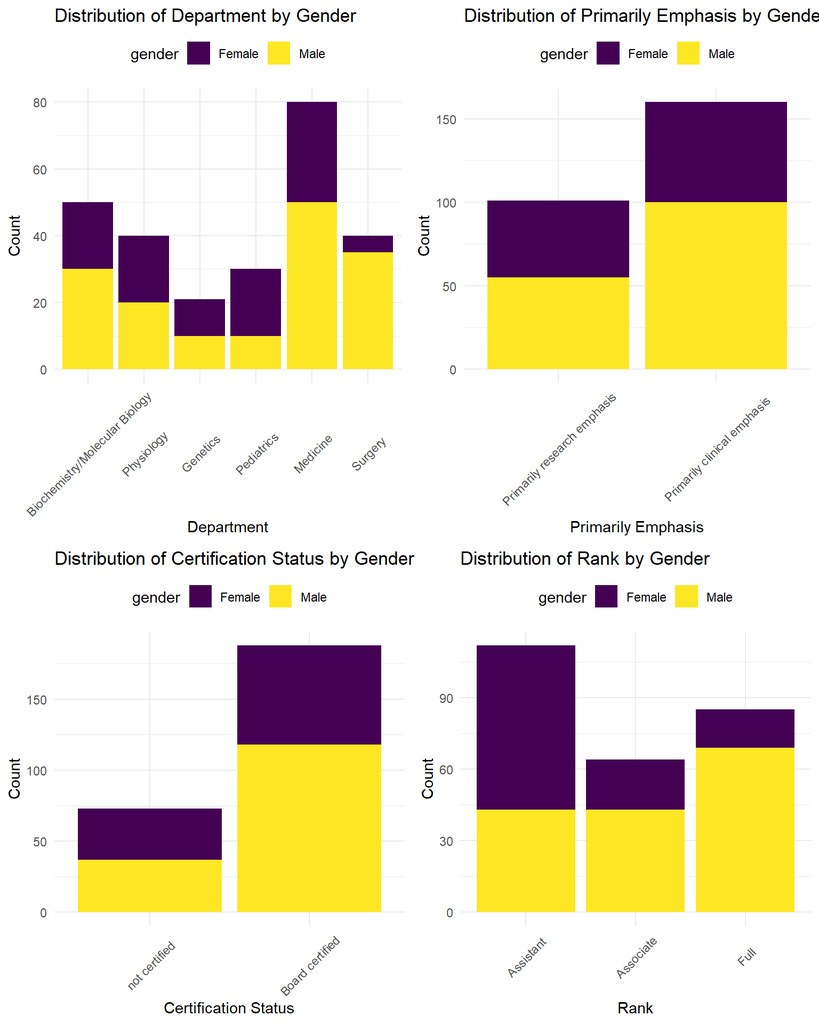

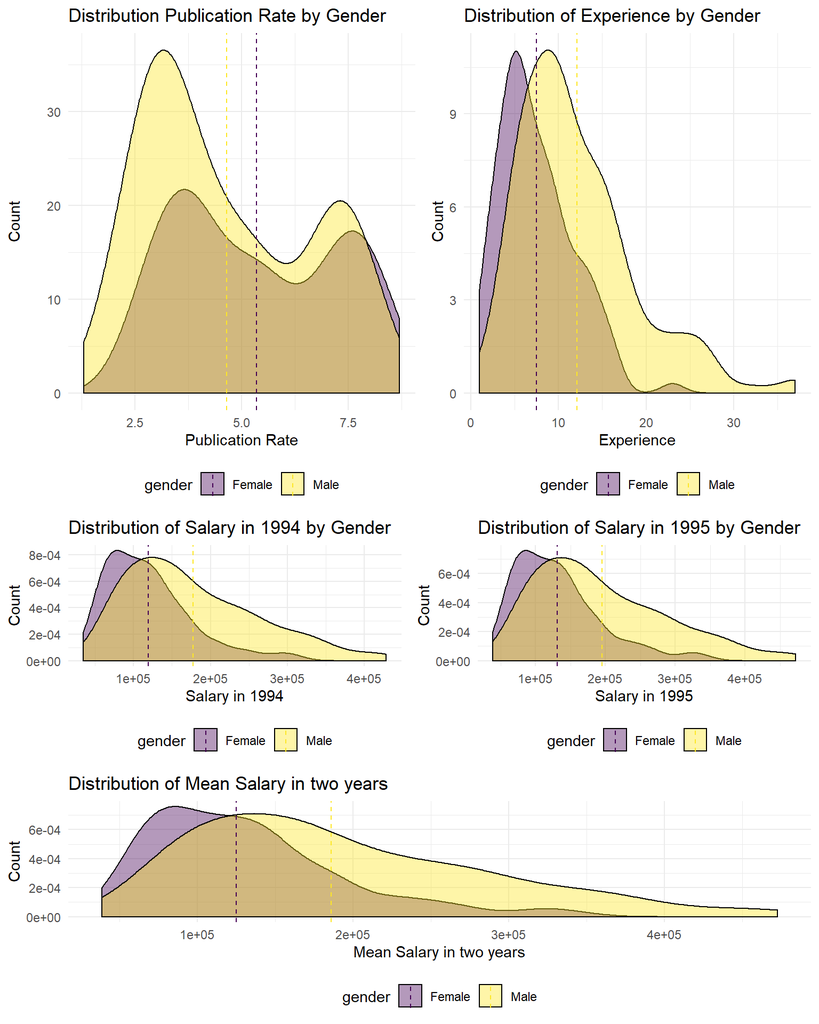

### Transformation

Based on the investigation of the distribution, to meet the assumption that response value y is normal, “salary” needs transformation.

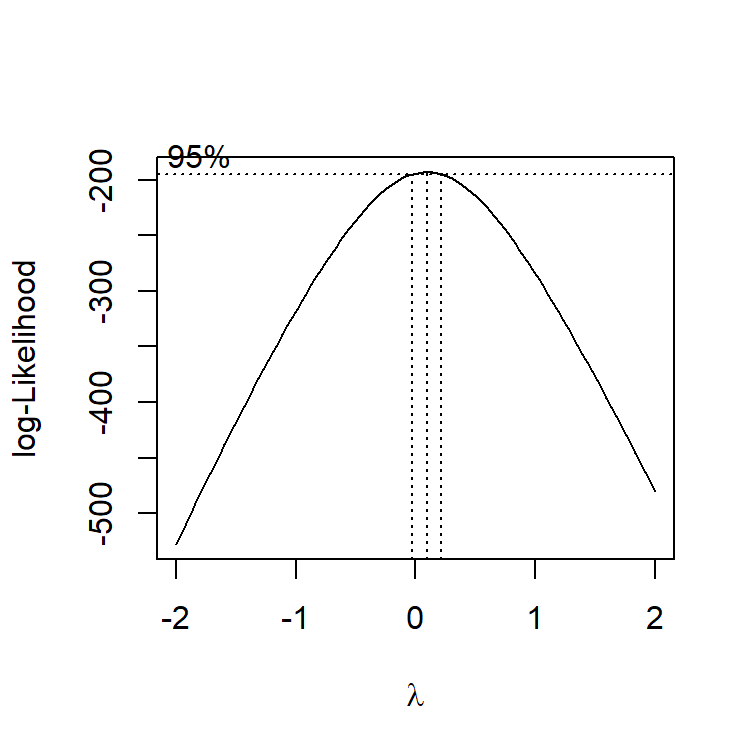

Based on the plot above, we need to do log-transformation for the mean value of sal94 and sal95 to meet the assumption of normality.

## Model Regression

```r
# all covariates
reg1 = lm(ln_salavg ~ gender + dept + clin + prate + cert + exper + rank, data = data)
summary(reg1)
```

```
##
## Call:
## lm(formula = ln_salavg ~ gender + dept + clin + prate + cert +
##     exper + rank, data = data)
##
## Residuals:
##      Min       1Q   Median       3Q      Max
## -0.33729 -0.07685 -0.01218  0.07599  0.89829
##
## Coefficients:
##                                  Estimate Std. Error t value Pr(>|t|)
## (Intercept)                     11.140871   0.134757  82.674  < 2e-16 ***
## genderMale                       0.019536   0.020224   0.966  0.33500
## deptPhysiology                  -0.175521   0.029090  -6.034 5.80e-09 ***
## deptGenetics                     0.169395   0.038791   4.367 1.85e-05 ***
## deptPediatrics                   0.153235   0.053632   2.857  0.00464 **
## deptMedicine                     0.496297   0.045284  10.960  < 2e-16 ***
## deptSurgery                      0.870767   0.061638  14.127  < 2e-16 ***
## clinPrimarily clinical emphasis  0.164726   0.041145   4.004 8.25e-05 ***
## prate                           -0.021730   0.017367  -1.251  0.21203
## certBoard certified              0.190855   0.021238   8.987  < 2e-16 ***
## exper                            0.018027   0.001826   9.873  < 2e-16 ***
## rankAssociate                    0.132488   0.023595   5.615 5.25e-08 ***
## rankFull                         0.219399   0.026316   8.337 5.28e-15 ***
## ---
## Signif. codes:  0 '***' 0.001 '**' 0.01 '*' 0.05 '.' 0.1 ' ' 1
##
## Residual standard error: 0.1335 on 248 degrees of freedom
## Multiple R-squared:  0.9343, Adjusted R-squared:  0.9311
## F-statistic: 293.9 on 12 and 248 DF,  p-value: < 2.2e-16
```

```r
vif(reg1) %>%
  knitr::kable()
```

|  | x |
| --- | --- |
| genderMale | 1.443762 |
| deptPhysiology | 1.607184 |
| deptGenetics | 1.629419 |
| deptPediatrics | 4.282664 |
| deptMedicine | 6.379551 |
| deptSurgery | 7.215586 |
| clinPrimarily clinical emphasis | 5.877635 |
| prate | 16.626048 |
| certBoard certified | 1.329952 |
| exper | 1.884661 |
| rankAssociate | 1.508016 |
| rankFull | 2.225837 |

```r
pred = data_raw[,c(2, 4:8)]
round(cor(pred), 3) %>%
  broom::tidy() %>%
  knitr::kable()
```

| .rownames | dept | clin | cert | prate | exper | rank |
| --- | --- | --- | --- | --- | --- | --- |
| dept | 1.000 | 0.613 | 0.374 | -0.867 | -0.128 | -0.174 |
| clin | 0.613 | 1.000 | 0.329 | -0.843 | -0.064 | -0.095 |
| cert | 0.374 | 0.329 | 1.000 | -0.388 | 0.100 | 0.014 |
| prate | -0.867 | -0.843 | -0.388 | 1.000 | 0.112 | 0.131 |
| exper | -0.128 | -0.064 | 0.100 | 0.112 | 1.000 | 0.648 |
| rank | -0.174 | -0.095 | 0.014 | 0.131 | 0.648 | 1.000 |

```r
# all covariates except clin
reg2 = lm(ln_salavg ~ gender + dept + prate + cert + exper + rank, data = data)
vif(reg2) %>%
  knitr::kable()
```

|  | x |
| --- | --- |
| genderMale | 1.380331 |
| deptPhysiology | 1.589997 |
| deptGenetics | 1.593090 |
| deptPediatrics | 3.166892 |
| deptMedicine | 4.954141 |
| deptSurgery | 5.094382 |
| prate | 4.693166 |
| certBoard certified | 1.315310 |
| exper | 1.859083 |
| rankAssociate | 1.497978 |
| rankFull | 2.214993 |

```r
# all covariates except prate
reg3 = lm(ln_salavg ~ gender + dept + clin + cert + exper + rank, data = data)
vif(reg3) %>%
  knitr::kable()
```

|  | x |
| --- | --- |
| genderMale | 1.356319 |
| deptPhysiology | 1.607121 |
| deptGenetics | 1.439383 |
| deptPediatrics | 1.894530 |
| deptMedicine | 2.704003 |
| deptSurgery | 2.392543 |
| clinPrimarily clinical emphasis | 1.659126 |
| certBoard certified | 1.327650 |
| exper | 1.852094 |
| rankAssociate | 1.499835 |
| rankFull | 2.209568 |

```r
# dropping prate leads to lower mean vif
```

```r
# gender only
reg4 = lm(ln_salavg ~ gender, data = data)
summary(reg4)
```

```
##
## Call:
## lm(formula = ln_salavg ~ gender, data = data)
##
## Residuals:
##     Min      1Q  Median      3Q     Max
## -1.1255 -0.3659 -0.0078  0.3342  1.0549
##
## Coefficients:
##             Estimate Std. Error t value Pr(>|t|)
## (Intercept) 11.63319    0.04595 253.162  < 2e-16 ***
## genderMale   0.38530    0.05963   6.462  5.1e-10 ***
## ---
## Signif. codes:  0 '***' 0.001 '**' 0.01 '*' 0.05 '.' 0.1 ' ' 1
##
## Residual standard error: 0.4731 on 259 degrees of freedom
## Multiple R-squared:  0.1388, Adjusted R-squared:  0.1355
## F-statistic: 41.75 on 1 and 259 DF,  p-value: 5.103e-10
```

```r
# gender + dept
reg5 = lm(ln_salavg ~ gender + dept, data = data)
summary(reg5)
```

```
##
## Call:
## lm(formula = ln_salavg ~ gender + dept, data = data)
##
## Residuals:
##      Min       1Q   Median       3Q      Max
## -0.70544 -0.19433 -0.02501  0.16341  0.60779
##
## Coefficients:
##                Estimate Std. Error t value Pr(>|t|)
## (Intercept)    11.34504    0.04110 276.036  < 2e-16 ***
## genderMale      0.20521    0.03355   6.116 3.60e-09 ***
## deptPhysiology -0.13194    0.05385  -2.450  0.01496 *
## deptGenetics    0.20092    0.06602   3.044  0.00258 **
## deptPediatrics  0.30535    0.05919   5.158 5.02e-07 ***
## deptMedicine    0.64943    0.04569  14.215  < 2e-16 ***
## deptSurgery     1.07668    0.05453  19.743  < 2e-16 ***
## ---
## Signif. codes:  0 '***' 0.001 '**' 0.01 '*' 0.05 '.' 0.1 ' ' 1
##
## Residual standard error: 0.2534 on 254 degrees of freedom
## Multiple R-squared:  0.7578, Adjusted R-squared:  0.752
## F-statistic: 132.4 on 6 and 254 DF,  p-value: < 2.2e-16
```

```r
# gender + clin
reg6 = lm(ln_salavg ~ gender + clin, data = data)
summary(reg6)
```

```
##
## Call:
## lm(formula = ln_salavg ~ gender + clin, data = data)
##
## Residuals:
##      Min       1Q   Median       3Q      Max
## -1.00911 -0.25023 -0.01895  0.24564  0.99426
##
## Coefficients:
##                                 Estimate Std. Error t value Pr(>|t|)
## (Intercept)                     11.28894    0.04470 252.526  < 2e-16 ***
## genderMale                       0.33718    0.04671   7.218 5.89e-12 ***
## clinPrimarily clinical emphasis  0.60819    0.04710  12.912  < 2e-16 ***
## ---
## Signif. codes:  0 '***' 0.001 '**' 0.01 '*' 0.05 '.' 0.1 ' ' 1
##
## Residual standard error: 0.3694 on 258 degrees of freedom
## Multiple R-squared:  0.4769, Adjusted R-squared:  0.4728
## F-statistic: 117.6 on 2 and 258 DF,  p-value: < 2.2e-16
```

```r
# gender + cert
reg7 = lm(ln_salavg ~ gender + cert, data = data)
summary(reg7)
```

```
##
## Call:
## lm(formula = ln_salavg ~ gender + cert, data = data)
##
## Residuals:
##      Min       1Q   Median       3Q      Max
## -1.11866 -0.27669 -0.01921  0.31081  1.01942
##
## Coefficients:
##                     Estimate Std. Error t value Pr(>|t|)
## (Intercept)         11.28992    0.05510 204.888  < 2e-16 ***
## genderMale           0.33285    0.05233   6.360 9.11e-10 ***
## certBoard certified  0.51981    0.05726   9.078  < 2e-16 ***
## ---
## Signif. codes:  0 '***' 0.001 '**' 0.01 '*' 0.05 '.' 0.1 ' ' 1
##
## Residual standard error: 0.4127 on 258 degrees of freedom
## Multiple R-squared:  0.3473, Adjusted R-squared:  0.3423
## F-statistic: 68.65 on 2 and 258 DF,  p-value: < 2.2e-16
```

```r
# gender + exper
reg8 = lm(ln_salavg ~ gender + exper, data = data)
summary(reg8)
```

```
##
## Call:
## lm(formula = ln_salavg ~ gender + exper, data = data)
##
## Residuals:
##      Min       1Q   Median       3Q      Max
## -1.03299 -0.37372  0.04036  0.33276  1.02947
##
## Coefficients:
##             Estimate Std. Error t value Pr(>|t|)
## (Intercept) 11.50693    0.05839 197.079  < 2e-16 ***
## genderMale   0.30755    0.06277   4.900  1.7e-06 ***
## exper        0.01686    0.00496   3.399 0.000784 ***
## ---
## Signif. codes:  0 '***' 0.001 '**' 0.01 '*' 0.05 '.' 0.1 ' ' 1
##
## Residual standard error: 0.4637 on 258 degrees of freedom
## Multiple R-squared:  0.1757, Adjusted R-squared:  0.1693
## F-statistic:  27.5 on 2 and 258 DF,  p-value: 1.488e-11
```

```r
# gender + rank
reg9 = lm(ln_salavg ~ gender + rank, data = data)
summary(reg9)
```

```
##
## Call:
## lm(formula = ln_salavg ~ gender + rank, data = data)
##
## Residuals:
##      Min       1Q   Median       3Q      Max
## -1.10798 -0.37872  0.01491  0.35397  1.03532
##
## Coefficients:
##                Estimate Std. Error t value Pr(>|t|)
## (Intercept)   11.615638   0.050964 227.919  < 2e-16 ***
## genderMale     0.349481   0.064420   5.425 1.34e-07 ***
## rankAssociate -0.005225   0.076187  -0.069   0.9454
## rankFull       0.123166   0.073223   1.682   0.0938 .
## ---
## Signif. codes:  0 '***' 0.001 '**' 0.01 '*' 0.05 '.' 0.1 ' ' 1
##
## Residual standard error: 0.4716 on 257 degrees of freedom
## Multiple R-squared:  0.151,  Adjusted R-squared:  0.1411
## F-statistic: 15.23 on 3 and 257 DF,  p-value: 3.747e-09
```

```r
# all confounders
summary(reg3)
```

```
##
## Call:
## lm(formula = ln_salavg ~ gender + dept + clin + cert + exper +
##     rank, data = data)
##
## Residuals:
##      Min       1Q   Median       3Q      Max
## -0.34605 -0.07696 -0.01873  0.07596  0.90393
##
## Coefficients:
##                                  Estimate Std. Error t value Pr(>|t|)
## (Intercept)                     10.975773   0.027395 400.656  < 2e-16 ***
## genderMale                       0.025763   0.019624   1.313     0.19
## deptPhysiology                  -0.175749   0.029122  -6.035 5.73e-09 ***
## deptGenetics                     0.185970   0.036501   5.095 6.90e-07 ***
## deptPediatrics                   0.203345   0.035712   5.694 3.48e-08 ***
## deptMedicine                     0.539304   0.029515  18.272  < 2e-16 ***
## deptSurgery                      0.933820   0.035533  26.280  < 2e-16 ***
## clinPrimarily clinical emphasis  0.208340   0.021885   9.520  < 2e-16 ***
## certBoard certified              0.189749   0.021244   8.932  < 2e-16 ***
## exper                            0.017726   0.001812   9.783  < 2e-16 ***
## rankAssociate                    0.134663   0.023557   5.716 3.10e-08 ***
## rankFull                         0.222214   0.026249   8.466 2.22e-15 ***
## ---
## Signif. codes:  0 '***' 0.001 '**' 0.01 '*' 0.05 '.' 0.1 ' ' 1
##
## Residual standard error: 0.1337 on 249 degrees of freedom
## Multiple R-squared:  0.9339, Adjusted R-squared:  0.931
## F-statistic: 319.7 on 11 and 249 DF,  p-value: < 2.2e-16
```

```r
# 3 + gender * dept
reg10 = lm(ln_salavg ~ gender*dept + clin + cert + exper + rank, data = data)
summary(reg10)
```

```
##
## Call:
## lm(formula = ln_salavg ~ gender * dept + clin + cert + exper +
##     rank, data = data)
##
## Residuals:
##      Min       1Q   Median       3Q      Max
## -0.34206 -0.07681 -0.01587  0.07247  0.90312
##
## Coefficients:
##                                  Estimate Std. Error t value Pr(>|t|)
## (Intercept)                     11.002990   0.034998 314.389  < 2e-16 ***
## genderMale                      -0.015893   0.040369  -0.394 0.694151
## deptPhysiology                  -0.218213   0.043233  -5.047 8.76e-07 ***
## deptGenetics                     0.139604   0.051326   2.720 0.006999 **
## deptPediatrics                   0.179095   0.045781   3.912 0.000119 ***
## deptMedicine                     0.524282   0.042333  12.385  < 2e-16 ***
## deptSurgery                      0.905280   0.070734  12.798  < 2e-16 ***
## clinPrimarily clinical emphasis  0.206082   0.022256   9.260  < 2e-16 ***
## certBoard certified              0.185790   0.021591   8.605 9.47e-16 ***
## exper                            0.017540   0.001831   9.582  < 2e-16 ***
## rankAssociate                    0.137201   0.023824   5.759 2.54e-08 ***
## rankFull                         0.225945   0.026685   8.467 2.37e-15 ***
## genderMale:deptPhysiology        0.077890   0.057948   1.344 0.180155
## genderMale:deptGenetics          0.087661   0.071822   1.221 0.223442
## genderMale:deptPediatrics        0.049162   0.065365   0.752 0.452705
## genderMale:deptMedicine          0.030637   0.049940   0.613 0.540139
## genderMale:deptSurgery           0.050314   0.075798   0.664 0.507446
## ---
## Signif. codes:  0 '***' 0.001 '**' 0.01 '*' 0.05 '.' 0.1 ' ' 1
##
## Residual standard error: 0.1343 on 244 degrees of freedom
## Multiple R-squared:  0.9346, Adjusted R-squared:  0.9303
## F-statistic: 217.9 on 16 and 244 DF,  p-value: < 2.2e-16
```

```r
# 3 + gender * clin
reg11 = lm(ln_salavg ~ gender*clin + dept + cert + exper + rank, data = data)
summary(reg11)
```

```
##
## Call:
## lm(formula = ln_salavg ~ gender * clin + dept + cert + exper +
##     rank, data = data)
##
## Residuals:
##      Min       1Q   Median       3Q      Max
## -0.35356 -0.07897 -0.01664  0.07976  0.89318
##
## Coefficients:
##                                             Estimate Std. Error t value
## (Intercept)                                10.962217   0.030588 358.381
## genderMale                                  0.048214   0.029882   1.613
## clinPrimarily clinical emphasis             0.227322   0.029017   7.834
## deptPhysiology                             -0.174042   0.029173  -5.966
## deptGenetics                                0.192013   0.037002   5.189
## deptPediatrics                              0.202340   0.035727   5.664
## deptMedicine                                0.540691   0.029549  18.298
## deptSurgery                                 0.938772   0.035880  26.165
## certBoard certified                         0.191900   0.021353   8.987
## exper                                       0.017960   0.001827   9.829
## rankAssociate                               0.130965   0.023848   5.492
## rankFull                                    0.215522   0.027096   7.954
## genderMale:clinPrimarily clinical emphasis -0.036750   0.036888  -0.996
##                                            Pr(>|t|)
## (Intercept)                                 < 2e-16 ***
## genderMale                                    0.108
## clinPrimarily clinical emphasis            1.38e-13 ***
## deptPhysiology                             8.35e-09 ***
## deptGenetics                               4.39e-07 ***
## deptPediatrics                             4.09e-08 ***
## deptMedicine                                < 2e-16 ***
## deptSurgery                                 < 2e-16 ***
## certBoard certified                         < 2e-16 ***
## exper                                       < 2e-16 ***
## rankAssociate                              9.85e-08 ***
## rankFull                                   6.41e-14 ***
## genderMale:clinPrimarily clinical emphasis    0.320
## ---
## Signif. codes:  0 '***' 0.001 '**' 0.01 '*' 0.05 '.' 0.1 ' ' 1
##
## Residual standard error: 0.1337 on 248 degrees of freedom
## Multiple R-squared:  0.9341, Adjusted R-squared:  0.931
## F-statistic: 293.2 on 12 and 248 DF,  p-value: < 2.2e-16
```

```r
# 3 + gender * cert
reg12 = lm(ln_salavg ~ gender*cert + dept + clin + exper + rank, data = data)
summary(reg12)
```

```
##
## Call:
## lm(formula = ln_salavg ~ gender * cert + dept + clin + exper +
##     rank, data = data)
##
## Residuals:
##      Min       1Q   Median       3Q      Max
## -0.34790 -0.07963 -0.01940  0.07547  0.90001
##
## Coefficients:
##                                  Estimate Std. Error t value Pr(>|t|)
## (Intercept)                     10.970526   0.031172 351.936  < 2e-16 ***
## genderMale                       0.035345   0.033399   1.058    0.291
## certBoard certified              0.197307   0.030107   6.553 3.23e-10 ***
## deptPhysiology                  -0.174932   0.029264  -5.978 7.84e-09 ***
## deptGenetics                     0.187449   0.036802   5.094 6.96e-07 ***
## deptPediatrics                   0.202155   0.035932   5.626 4.96e-08 ***
## deptMedicine                     0.538928   0.029586  18.216  < 2e-16 ***
## deptSurgery                      0.934320   0.035623  26.228  < 2e-16 ***
## clinPrimarily clinical emphasis  0.209165   0.022047   9.487  < 2e-16 ***
## exper                            0.017703   0.001816   9.746  < 2e-16 ***
## rankAssociate                    0.134115   0.023649   5.671 3.94e-08 ***
## rankFull                         0.222681   0.026328   8.458 2.37e-15 ***
## genderMale:certBoard certified  -0.013808   0.038910  -0.355    0.723
## ---
## Signif. codes:  0 '***' 0.001 '**' 0.01 '*' 0.05 '.' 0.1 ' ' 1
##
## Residual standard error: 0.1339 on 248 degrees of freedom
## Multiple R-squared:  0.9339, Adjusted R-squared:  0.9307
## F-statistic: 292.1 on 12 and 248 DF,  p-value: < 2.2e-16
```

```r
# 3 + gender * exper
reg13 = lm(ln_salavg ~ gender*exper + dept + clin + cert + rank, data = data)
summary(reg13)
```

```
##
## Call:
## lm(formula = ln_salavg ~ gender * exper + dept + clin + cert +
##     rank, data = data)
##
## Residuals:
##      Min       1Q   Median       3Q      Max
## -0.32130 -0.07860 -0.00987  0.07100  0.86910
##
## Coefficients:
##                                  Estimate Std. Error t value Pr(>|t|)
## (Intercept)                     10.903325   0.034805 313.272  < 2e-16 ***
## genderMale                       0.128932   0.036912   3.493 0.000566 ***
## exper                            0.027774   0.003545   7.834 1.38e-13 ***
## deptPhysiology                  -0.165069   0.028755  -5.741 2.75e-08 ***
## deptGenetics                     0.189770   0.035827   5.297 2.60e-07 ***
## deptPediatrics                   0.218603   0.035342   6.185 2.54e-09 ***
## deptMedicine                     0.546771   0.029045  18.825  < 2e-16 ***
## deptSurgery                      0.939830   0.034907  26.924  < 2e-16 ***
## clinPrimarily clinical emphasis  0.208175   0.021470   9.696  < 2e-16 ***
## certBoard certified              0.182166   0.020969   8.688 5.09e-16 ***
## rankAssociate                    0.118231   0.023648   5.000 1.09e-06 ***
## rankFull                         0.208036   0.026112   7.967 5.90e-14 ***
## genderMale:exper                -0.011728   0.003580  -3.276 0.001204 **
## ---
## Signif. codes:  0 '***' 0.001 '**' 0.01 '*' 0.05 '.' 0.1 ' ' 1
##
## Residual standard error: 0.1312 on 248 degrees of freedom
## Multiple R-squared:  0.9366, Adjusted R-squared:  0.9336
## F-statistic: 305.4 on 12 and 248 DF,  p-value: < 2.2e-16
```

```r
# 3 + gender * rank
reg14 = lm(ln_salavg ~ gender*rank + dept + clin + cert + exper, data = data)
summary(reg14)
```

```
##
## Call:
## lm(formula = ln_salavg ~ gender * rank + dept + clin + cert +
##     exper, data = data)
##
## Residuals:
##      Min       1Q   Median       3Q      Max
## -0.32667 -0.08080 -0.01075  0.07646  0.86686
##
## Coefficients:
##                                  Estimate Std. Error t value Pr(>|t|)
## (Intercept)                     10.959335   0.027936 392.307  < 2e-16 ***
## genderMale                       0.074479   0.027568   2.702  0.00738 **
## rankAssociate                    0.173142   0.033904   5.107 6.55e-07 ***
## rankFull                         0.282281   0.039594   7.129 1.11e-11 ***
## deptPhysiology                  -0.175544   0.028871  -6.080 4.53e-09 ***
## deptGenetics                     0.184572   0.036206   5.098 6.84e-07 ***
## deptPediatrics                   0.208468   0.035528   5.868 1.41e-08 ***
## deptMedicine                     0.543204   0.029364  18.499  < 2e-16 ***
## deptSurgery                      0.931388   0.035267  26.409  < 2e-16 ***
## clinPrimarily clinical emphasis  0.197031   0.022175   8.885  < 2e-16 ***
## certBoard certified              0.191213   0.021363   8.951  < 2e-16 ***
## exper                            0.018171   0.001806  10.064  < 2e-16 ***
## genderMale:rankAssociate        -0.082943   0.044750  -1.853  0.06501 .
## genderMale:rankFull             -0.105271   0.046654  -2.256  0.02492 *
## ---
## Signif. codes:  0 '***' 0.001 '**' 0.01 '*' 0.05 '.' 0.1 ' ' 1
##
## Residual standard error: 0.1325 on 247 degrees of freedom
## Multiple R-squared:  0.9355, Adjusted R-squared:  0.9322
## F-statistic: 275.8 on 13 and 247 DF,  p-value: < 2.2e-16
```

```r
# both exper and rank are modifiers
# 3 + gender * rank + gender * exper
reg15 = lm(ln_salavg ~ gender*rank + gender*exper + dept + clin + cert, data = data)
summary(reg15)
```

```
##
## Call:
## lm(formula = ln_salavg ~ gender * rank + gender * exper + dept +
##     clin + cert, data = data)
##
## Residuals:
##      Min       1Q   Median       3Q      Max
## -0.31795 -0.07929 -0.01275  0.07078  0.85987
##
## Coefficients:
##                                  Estimate Std. Error t value Pr(>|t|)
## (Intercept)                     10.906051   0.036673 297.390  < 2e-16 ***
## genderMale                       0.133412   0.038125   3.499 0.000554 ***
## rankAssociate                    0.141497   0.036537   3.873 0.000138 ***
## rankFull                         0.217020   0.049074   4.422 1.47e-05 ***
## exper                            0.026849   0.004302   6.241 1.89e-09 ***
## deptPhysiology                  -0.166053   0.028962  -5.733 2.87e-08 ***
## deptGenetics                     0.188370   0.035963   5.238 3.49e-07 ***
## deptPediatrics                   0.219621   0.035606   6.168 2.82e-09 ***
## deptMedicine                     0.548131   0.029218  18.760  < 2e-16 ***
## deptSurgery                      0.939254   0.035170  26.706  < 2e-16 ***
## clinPrimarily clinical emphasis  0.205465   0.022327   9.203  < 2e-16 ***
## certBoard certified              0.181479   0.021644   8.385 3.97e-15 ***
## genderMale:rankAssociate        -0.040275   0.048384  -0.832 0.405994
## genderMale:rankFull             -0.018879   0.060486  -0.312 0.755215
## genderMale:exper                -0.010471   0.004719  -2.219 0.027410 *
## ---
## Signif. codes:  0 '***' 0.001 '**' 0.01 '*' 0.05 '.' 0.1 ' ' 1
##
## Residual standard error: 0.1315 on 246 degrees of freedom
## Multiple R-squared:  0.9368, Adjusted R-squared:  0.9332
## F-statistic: 260.5 on 14 and 246 DF,  p-value: < 2.2e-16
```

```r
# gender * rank becomes non-significant
# reg15 is not superior compared to reg13
reg1315 = anova(reg13, reg15)

# reg15 is superior compared to 14
reg1415 = anova(reg14, reg15)

# make table for the result for anova
nested_anova = data.frame(
  Fstatistics = c(reg1315$F, reg1415$F),
  P.value = c(reg1315$`Pr(>F)`, reg1415$`Pr(>F)`)
) %>%
  drop_na()

nested_anova$model = c("reg13 VS reg15", "reg14 VS reg15")
nested_anova = nested_anova %>%
  dplyr::select(model, everything())
nested_anova %>%
  knitr::kable()
```

|  | model | Fstatistics | P.value |
| --- | --- | --- | --- |
| 2 | reg13 VS reg15 | 0.3543116 | 0.7020138 |
| 4 | reg14 VS reg15 | 4.9232674 | 0.0274105 |

```r
# reg13 reg14 is similar
summary_reg13 = summary(reg13)
summary_reg14 = summary(reg14)
# make table for the result
anova_table =
data.frame(adj.R2 = c(summary_reg13$adj.r.squared,summary_reg14$adj.r.squared),
Fstatistics = c(summary_reg13$fstatistic,summary_reg14$fstatistic)
)
anova_table1 = data.frame(anova_table[c(1,4),])
anova_table1$F.test = c(1.79, 1.76)
anova_table1$model = c("model1","model2")
anova_table1 = anova_table1 %>%
  dplyr::select(model, adj.R2, Fstatistics, F.test) %>%   knitr::kable()
anova_table1
```

|  | model | adj.R2 | Fstatistics | F.test |
| --- | --- | --- | --- | --- |
| 1 | model1 | 0.9335614 | 305.4488 | 1.79 |
| 4 | model2 | 0.9321528 | 275.7799 | 1.76 |

```r
# compare with and without interaction term
anova(reg3, reg13)
```

```
## Analysis of Variance Table
##
## Model 1: ln_salavg ~ gender + dept + clin + cert + exper + rank
## Model 2: ln_salavg ~ gender * exper + dept + clin + cert + rank
##   Res.Df    RSS Df Sum of Sq      F   Pr(>F)
## 1    249 4.4506
## 2    248 4.2660  1   0.18458 10.731 0.001204 **
## ---
## Signif. codes:  0 '***' 0.001 '**' 0.01 '*' 0.05 '.' 0.1 ' ' 1
```

```r
# AIC
AIC(reg13)
```

```
## [1] -305.0287
```

```r
AIC(reg14)
```

```
## [1] -298.6076
```

```r
# BIC
AIC(reg13, k = log(length(data$ln_salavg)))
```

```
## [1] -255.1254
```

```r
AIC(reg14, k = log(length(data$ln_salavg)))
```

```
## [1] -245.1398
```

```r
# stratification by exper
data_low = filter(data, exper < 10)
data_medium = filter(data, exper >= 10 & exper < 20)
data_high = filter(data, exper >= 20)
reg_low = lm(ln_salavg ~ gender + dept + clin + cert + rank, data = data_low)
summary(reg_low)
```

```
##
## Call:
## lm(formula = ln_salavg ~ gender + dept + clin + cert + rank,
##     data = data_low)
##
## Residuals:
##      Min       1Q   Median       3Q      Max
## -0.33887 -0.08354 -0.00479  0.08268  0.74977
##
## Coefficients:
##                                 Estimate Std. Error t value Pr(>|t|)
## (Intercept)                     11.07409    0.03858 287.021  < 2e-16 ***
## genderMale                       0.07255    0.02679   2.709 0.007683 **
## deptPhysiology                  -0.22757    0.04664  -4.879 3.11e-06 ***
## deptGenetics                     0.19782    0.05757   3.436 0.000796 ***
## deptPediatrics                   0.23605    0.05733   4.118 6.82e-05 ***
## deptMedicine                     0.58380    0.05086  11.479  < 2e-16 ***
## deptSurgery                      0.95601    0.06027  15.862  < 2e-16 ***
## clinPrimarily clinical emphasis  0.16923    0.03561   4.752 5.31e-06 ***
## certBoard certified              0.14907    0.03083   4.836 3.74e-06 ***
## rankAssociate                    0.14613    0.03223   4.534 1.31e-05 ***
## rankFull                         0.28070    0.04321   6.497 1.66e-09 ***
## ---
## Signif. codes:  0 '***' 0.001 '**' 0.01 '*' 0.05 '.' 0.1 ' ' 1
##
## Residual standard error: 0.1431 on 128 degrees of freedom
## Multiple R-squared:  0.9203, Adjusted R-squared:  0.9141
## F-statistic: 147.8 on 10 and 128 DF,  p-value: < 2.2e-16
```

```r
reg_medium = lm(ln_salavg ~ gender + dept + clin + cert + rank, data = data_medium)
summary(reg_medium)
```

```
##
## Call:
## lm(formula = ln_salavg ~ gender + dept + clin + cert + rank,
##     data = data_medium)
##
## Residuals:
##      Min       1Q   Median       3Q      Max
## -0.32538 -0.09266 -0.00250  0.09039  0.24601
##
## Coefficients:
##                                 Estimate Std. Error t value Pr(>|t|)
## (Intercept)                     11.24358    0.04416 254.626  < 2e-16 ***
## genderMale                      -0.02091    0.03006  -0.696  0.48841
## deptPhysiology                  -0.13374    0.03997  -3.346  0.00119 **
## deptGenetics                     0.17225    0.05037   3.420  0.00094 ***
## deptPediatrics                   0.16019    0.04729   3.387  0.00104 **
## deptMedicine                     0.48815    0.03931  12.418  < 2e-16 ***
## deptSurgery                      0.92571    0.04814  19.231  < 2e-16 ***
## clinPrimarily clinical emphasis  0.24927    0.03009   8.283 9.90e-13 ***
## certBoard certified              0.21901    0.03165   6.921 6.14e-10 ***
## rankAssociate                    0.11412    0.04078   2.799  0.00627 **
## rankFull                         0.21777    0.03933   5.537 2.95e-07 ***
## ---
## Signif. codes:  0 '***' 0.001 '**' 0.01 '*' 0.05 '.' 0.1 ' ' 1
##
## Residual standard error: 0.12 on 91 degrees of freedom
## Multiple R-squared:  0.9419, Adjusted R-squared:  0.9355
## F-statistic: 147.4 on 10 and 91 DF,  p-value: < 2.2e-16
```

```r
reg_high = lm(ln_salavg ~ gender + dept + clin + cert + rank, data = data_high)
summary(reg_high)
```

```
##
## Call:
## lm(formula = ln_salavg ~ gender + dept + clin + cert + rank,
##     data = data_high)
##
## Residuals:
##      Min       1Q   Median       3Q      Max
## -0.17144 -0.08454  0.03411  0.06116  0.12144
##
## Coefficients:
##                                 Estimate Std. Error t value Pr(>|t|)
## (Intercept)                     11.41268    0.18527  61.600 2.55e-15 ***
## genderMale                       0.23344    0.14897   1.567  0.14541
## deptPhysiology                  -0.19732    0.08750  -2.255  0.04549 *
## deptGenetics                     0.03156    0.14016   0.225  0.82598
## deptMedicine                     0.56460    0.09137   6.179 6.91e-05 ***
## deptSurgery                      0.84820    0.10010   8.473 3.77e-06 ***
## clinPrimarily clinical emphasis  0.08608    0.08052   1.069  0.30791
## certBoard certified              0.35944    0.08259   4.352  0.00115 **
## rankFull                        -0.05353    0.08459  -0.633  0.53975
## ---
## Signif. codes:  0 '***' 0.001 '**' 0.01 '*' 0.05 '.' 0.1 ' ' 1
##
## Residual standard error: 0.1204 on 11 degrees of freedom
## Multiple R-squared:  0.9652, Adjusted R-squared:  0.9399
## F-statistic: 38.17 on 8 and 11 DF,  p-value: 5.988e-07
```

```r
## stratify by rank"Assistant","Associate","Full"
data_stra1_ = filter(data, rank == "Assistant")
data_stra2_ = filter(data, rank == "Associate")
data_stra3_ = filter(data, rank == "Full")
reg_stra1_ = lm(ln_salavg ~ gender + dept + clin + cert + exper, data = data_stra1_)
summary(reg_stra1_)
```

```
##
## Call:
## lm(formula = ln_salavg ~ gender + dept + clin + cert + exper,
##     data = data_stra1_)
##
## Residuals:
##      Min       1Q   Median       3Q      Max
## -0.30995 -0.09230 -0.01370  0.07692  0.78854
##
## Coefficients:
##                                  Estimate Std. Error t value Pr(>|t|)
## (Intercept)                     10.958748   0.058460 187.457  < 2e-16 ***
## genderMale                       0.082656   0.035347   2.338 0.021316 *
## deptPhysiology                  -0.201314   0.063379  -3.176 0.001973 **
## deptGenetics                     0.143432   0.069186   2.073 0.040681 *
## deptPediatrics                   0.255421   0.066715   3.829 0.000223 ***
## deptMedicine                     0.600806   0.061033   9.844  < 2e-16 ***
## deptSurgery                      0.943082   0.070044  13.464  < 2e-16 ***
## clinPrimarily clinical emphasis  0.179071   0.042166   4.247 4.80e-05 ***
## certBoard certified              0.119828   0.040890   2.931 0.004176 **
## exper                            0.024735   0.005354   4.620 1.12e-05 ***
## ---
## Signif. codes:  0 '***' 0.001 '**' 0.01 '*' 0.05 '.' 0.1 ' ' 1
##
## Residual standard error: 0.1541 on 102 degrees of freedom
## Multiple R-squared:  0.9126, Adjusted R-squared:  0.9049
## F-statistic: 118.3 on 9 and 102 DF,  p-value: < 2.2e-16
```

```r
reg_stra2_ = lm(ln_salavg ~ gender + dept + clin + cert + exper, data = data_stra2_)
summary(reg_stra2_)
```

```
##
## Call:
## lm(formula = ln_salavg ~ gender + dept + clin + cert + exper,
##     data = data_stra2_)
##
## Residuals:
##       Min        1Q    Median        3Q       Max
## -0.268895 -0.061719  0.008443  0.069568  0.186993
##
## Coefficients:
##                                  Estimate Std. Error t value Pr(>|t|)
## (Intercept)                     11.093068   0.045411 244.283  < 2e-16 ***
## genderMale                      -0.013277   0.031011  -0.428 0.670252
## deptPhysiology                  -0.189342   0.043481  -4.355 5.99e-05 ***
## deptGenetics                     0.170588   0.055740   3.060 0.003439 **
## deptPediatrics                   0.210069   0.055921   3.757 0.000424 ***
## deptMedicine                     0.507098   0.050051  10.132 4.30e-14 ***
## deptSurgery                      0.931900   0.057099  16.321  < 2e-16 ***
## clinPrimarily clinical emphasis  0.220247   0.037705   5.841 3.06e-07 ***
## certBoard certified              0.200488   0.031803   6.304 5.53e-08 ***
## exper                            0.021512   0.002619   8.214 4.45e-11 ***
## ---
## Signif. codes:  0 '***' 0.001 '**' 0.01 '*' 0.05 '.' 0.1 ' ' 1
##
## Residual standard error: 0.1033 on 54 degrees of freedom
## Multiple R-squared:  0.9621, Adjusted R-squared:  0.9558
## F-statistic: 152.2 on 9 and 54 DF,  p-value: < 2.2e-16
```

```r
reg_stra3_ = lm(ln_salavg ~ gender + dept + clin + cert + exper, data = data_stra3_)
summary(reg_stra3_)
```

```
##
## Call:
## lm(formula = ln_salavg ~ gender + dept + clin + cert + exper,
##     data = data_stra3_)
##
## Residuals:
##       Min        1Q    Median        3Q       Max
## -0.279999 -0.079443 -0.000564  0.075727  0.253899
##
## Coefficients:
##                                  Estimate Std. Error t value Pr(>|t|)
## (Intercept)                     11.247757   0.048321 232.773  < 2e-16 ***
## genderMale                      -0.040413   0.036217  -1.116  0.26805
## deptPhysiology                  -0.127860   0.038834  -3.292  0.00152 **
## deptGenetics                     0.248823   0.055205   4.507 2.38e-05 ***
## deptPediatrics                   0.166793   0.066371   2.513  0.01412 *
## deptMedicine                     0.528191   0.039209  13.471  < 2e-16 ***
## deptSurgery                      0.948635   0.050331  18.848  < 2e-16 ***
## clinPrimarily clinical emphasis  0.179305   0.033412   5.367 8.61e-07 ***
## certBoard certified              0.258010   0.033989   7.591 7.14e-11 ***
## exper                            0.014871   0.002253   6.601 5.15e-09 ***
## ---
## Signif. codes:  0 '***' 0.001 '**' 0.01 '*' 0.05 '.' 0.1 ' ' 1
##
## Residual standard error: 0.1165 on 75 degrees of freedom
## Multiple R-squared:  0.9511, Adjusted R-squared:  0.9452
## F-statistic: 161.9 on 9 and 75 DF,  p-value: < 2.2e-16
```

```r
# function to export formattable
export_formattable = function(f, file, width = "100%", height = NULL, background = "white", delay = 0.2)
    {w = as.htmlwidget(f, width = width, height = height)
     path = html_print(w, background = background, viewer = NULL)
     url = paste0("file:///", gsub("\\\\", "/", normalizePath(path)))
     webshot(url,
             file = file,
             selector = ".formattable_widget",
             delay = delay)
     }
# confounding
tidy4 = tidy(reg4)
tidy5 = tidy(reg5)
tidy6 = tidy(reg6)
tidy7 = tidy(reg7)
tidy8 = tidy(reg8)
tidy9 = tidy(reg9)
con_df = rbind(tidy4[2, c(2:5)], tidy5[2, c(2:5)], tidy6[2, c(2:5)], tidy7[2, c(2:5)], tidy8[2, c(2:5)], tidy9[2, c(2:5)])
con_df$coefficient.change = abs((con_df$estimate-tidy4$estimate[2])/tidy4$estimate[2])
con_df$confounder = con_df$coefficient.change
con_df$covariate = c("gender", "dept", "clin", "cert", "exper", "rank")
con_ft = formattable(con_df[, c(7,1,4,5,6)],
                     align = c("l", rep("c", 4)),
                     list(`covariate` = formatter("span", style = ~ style(color = "grey", font.weight = "bold")), `coefficient.change` = percent, `confounder` = formatter("span", x ~ icontext(ifelse(x > 0.1, "ok", "remove"), ifelse(x > 0.1, "Yes", "No")), style = x ~ style(color = ifelse(x > 0.1, "green", "red"))))
                     )
# export formattable con_ft
export_formattable(con_ft,"con_ft.png")
```

```
## PhantomJS not found. You can install it with webshot::install_phantomjs(). If it is installed, please make sure the phantomjs executable can be found via the PATH variable.
```

```r
# interaction
tidy10 = tidy(reg10)
tidy11 = tidy(reg11)
tidy12 = tidy(reg12)
tidy13 = tidy(reg13)
tidy14 = tidy(reg14)
int_df = rbind(tidy10[c(13:17), c(1:5)], tidy11[13, c(1:5)], tidy12[13, c(1:5)], tidy13[13, c(1:5)], tidy14[c(13:14), c(1:5)])
int_df$interaction = int_df$p.value
names(int_df)[1] = "covariate"
int_ft = formattable(int_df[, c(1,2,5,6)],
                     align = c("l", rep("c", 3)),
                     list(`covariate` = formatter("span", style = ~ style(color = "grey", font.weight = "bold")), `interaction` = formatter("span", x ~ icontext(ifelse(x < 0.05, "ok", "remove"), ifelse(x < 0.05, "Yes", "No")), style = x ~ style(color = ifelse(x < 0.05, "green", "red"))))
                     )
# export formattable int_ft
export_formattable(int_ft,"int_ft.png")
```

```
## PhantomJS not found. You can install it with webshot::install_phantomjs(). If it is installed, please make sure the phantomjs executable can be found via the PATH variable.
```

```r
result_df = rbind(tidy4[2, c(2:5)], tidy13[2, c(2:5)], tidy14[2, c(2:5)])
result_df$model = c("unadjusted", "model1", "model2")
result_ft = formattable(result_df[, c(5,1,2,3,4)],
                     align = c("l", rep("c", 4)),
                     list(`model` = formatter("span", style = ~ style(color = "grey", font.weight = "bold")))
                     )
# export formattable result_ft
export_formattable(result_ft,"result_ft.png")
```

## Model Diagnostic

### Functional form for continuous predictor

#### Polynomial regression

For model 1 (interaction gender*exper)

```r
data_poly = data %>%
  mutate(exper_pow2 = exper^2,
         exper_pow3 = exper^3,
         exper_pow4 = exper^4)

poly_exper1 = lm(ln_salavg ~ gender*exper + dept + clin + cert + rank + exper + exper_pow2 + exper_pow3 + exper_pow4 , data = data_poly)

summary(poly_exper1)
```

```
##
## Call:
## lm(formula = ln_salavg ~ gender * exper + dept + clin + cert +
##     rank + exper + exper_pow2 + exper_pow3 + exper_pow4, data = data_poly)
##
## Residuals:
##      Min       1Q   Median       3Q      Max
## -0.32064 -0.07626 -0.01022  0.07155  0.88166
##
## Coefficients:
##                                   Estimate Std. Error t value Pr(>|t|)
## (Intercept)                      1.090e+01  6.284e-02 173.446  < 2e-16 ***
## genderMale                       1.153e-01  4.310e-02   2.676  0.00795 **
## exper                            2.686e-02  2.174e-02   1.236  0.21778
## deptPhysiology                  -1.624e-01  2.917e-02  -5.566 6.84e-08 ***
## deptGenetics                     1.899e-01  3.623e-02   5.242 3.44e-07 ***
## deptPediatrics                   2.204e-01  3.564e-02   6.185 2.58e-09 ***
## deptMedicine                     5.484e-01  2.927e-02  18.735  < 2e-16 ***
## deptSurgery                      9.405e-01  3.512e-02  26.779  < 2e-16 ***
## clinPrimarily clinical emphasis  2.089e-01  2.171e-02   9.622  < 2e-16 ***
## certBoard certified              1.810e-01  2.142e-02   8.447 2.68e-15 ***
## rankAssociate                    1.113e-01  2.572e-02   4.329 2.19e-05 ***
## rankFull                         1.992e-01  2.882e-02   6.911 4.14e-11 ***
## exper_pow2                       4.107e-04  2.439e-03   0.168  0.86641
## exper_pow3                      -2.663e-05  1.027e-04  -0.259  0.79560
## exper_pow4                       4.098e-07  1.425e-06   0.288  0.77396
## genderMale:exper                -1.018e-02  4.321e-03  -2.356  0.01928 *
## ---
## Signif. codes:  0 '***' 0.001 '**' 0.01 '*' 0.05 '.' 0.1 ' ' 1
##
## Residual standard error: 0.1318 on 245 degrees of freedom
## Multiple R-squared:  0.9368, Adjusted R-squared:  0.9329
## F-statistic:   242 on 15 and 245 DF,  p-value: < 2.2e-16
```

```r
anova(reg13, poly_exper1)
```

```
## Analysis of Variance Table
##
## Model 1: ln_salavg ~ gender * exper + dept + clin + cert + rank
## Model 2: ln_salavg ~ gender * exper + dept + clin + cert + rank + exper +
##     exper_pow2 + exper_pow3 + exper_pow4
##   Res.Df    RSS Df Sum of Sq      F Pr(>F)
## 1    248 4.2660
## 2    245 4.2558  3  0.010128 0.1943 0.9002
```

```r
data_poly_ = data %>%
  mutate(
    exper_ = exper - mean(exper),
    exper_pow2_ = exper_^2,
    exper_pow3_ = exper_^3,
    exper_pow4_ = exper_^4)


poly_exper_1 = lm(ln_salavg ~ gender*exper + dept + clin + cert + rank + exper_pow2_ + exper_pow3_ + exper_pow4_, data = data_poly_)

summary(poly_exper_1)
```

```
##
## Call:
## lm(formula = ln_salavg ~ gender * exper + dept + clin + cert +
##     rank + exper_pow2_ + exper_pow3_ + exper_pow4_, data = data_poly_)
##
## Residuals:
##      Min       1Q   Median       3Q      Max
## -0.32064 -0.07626 -0.01022  0.07155  0.88166
##
## Coefficients:
##                                   Estimate Std. Error t value Pr(>|t|)
## (Intercept)                      1.090e+01  5.016e-02 217.307  < 2e-16 ***
## genderMale                       1.153e-01  4.310e-02   2.676  0.00795 **
## exper                            2.866e-02  4.708e-03   6.087 4.41e-09 ***
## deptPhysiology                  -1.624e-01  2.917e-02  -5.566 6.84e-08 ***
## deptGenetics                     1.899e-01  3.623e-02   5.242 3.44e-07 ***
## deptPediatrics                   2.204e-01  3.564e-02   6.185 2.58e-09 ***
## deptMedicine                     5.484e-01  2.927e-02  18.735  < 2e-16 ***
## deptSurgery                      9.405e-01  3.512e-02  26.779  < 2e-16 ***
## clinPrimarily clinical emphasis  2.089e-01  2.171e-02   9.622  < 2e-16 ***
## certBoard certified              1.810e-01  2.142e-02   8.447 2.68e-15 ***
## rankAssociate                    1.113e-01  2.572e-02   4.329 2.19e-05 ***
## rankFull                         1.992e-01  2.882e-02   6.911 4.14e-11 ***
## exper_pow2_                     -1.494e-04  3.691e-04  -0.405  0.68605
## exper_pow3_                     -9.865e-06  4.562e-05  -0.216  0.82899
## exper_pow4_                      4.098e-07  1.425e-06   0.288  0.77396
## genderMale:exper                -1.018e-02  4.321e-03  -2.356  0.01928 *
## ---
## Signif. codes:  0 '***' 0.001 '**' 0.01 '*' 0.05 '.' 0.1 ' ' 1
##
## Residual standard error: 0.1318 on 245 degrees of freedom
## Multiple R-squared:  0.9368, Adjusted R-squared:  0.9329
## F-statistic:   242 on 15 and 245 DF,  p-value: < 2.2e-16
```

```r
anova(reg13, poly_exper_1)
```

```
## Analysis of Variance Table
##
## Model 1: ln_salavg ~ gender * exper + dept + clin + cert + rank
## Model 2: ln_salavg ~ gender * exper + dept + clin + cert + rank + exper_pow2_ +
##     exper_pow3_ + exper_pow4_
##   Res.Df    RSS Df Sum of Sq      F Pr(>F)
## 1    248 4.2660
## 2    245 4.2558  3  0.010128 0.1943 0.9002
```

We added its centering power 2, 3, 4 to original model 1. But the summary result indicates that there is no association between higher order of `exper` and `ln_salavg`. Alao, we fail to reject original model 1 by using anova to compare original model with polinomial model.

For model 2 (interaction gender*rank)

```r
poly_exper2 = lm(ln_salavg ~ gender*rank + dept + clin + cert + rank + exper + exper_pow2 + exper_pow3 + exper_pow4 , data = data_poly)

summary(poly_exper2)
```

```
##
## Call:
## lm(formula = ln_salavg ~ gender * rank + dept + clin + cert +
##     rank + exper + exper_pow2 + exper_pow3 + exper_pow4, data = data_poly)
##
## Residuals:
##      Min       1Q   Median       3Q      Max
## -0.31939 -0.07809 -0.01021  0.06701  0.89793
##
## Coefficients:
##                                   Estimate Std. Error t value Pr(>|t|)
## (Intercept)                      1.091e+01  6.316e-02 172.678  < 2e-16 ***
## genderMale                       6.943e-02  2.784e-02   2.494   0.0133 *
## rankAssociate                    1.505e-01  3.566e-02   4.221 3.43e-05 ***
## rankFull                         2.476e-01  4.290e-02   5.771 2.38e-08 ***
## deptPhysiology                  -1.662e-01  2.924e-02  -5.685 3.73e-08 ***
## deptGenetics                     1.844e-01  3.630e-02   5.079 7.54e-07 ***
## deptPediatrics                   2.185e-01  3.580e-02   6.104 4.05e-09 ***
## deptMedicine                     5.497e-01  2.946e-02  18.662  < 2e-16 ***
## deptSurgery                      9.353e-01  3.527e-02  26.519  < 2e-16 ***
## clinPrimarily clinical emphasis  2.008e-01  2.232e-02   8.998  < 2e-16 ***
## certBoard certified              1.835e-01  2.186e-02   8.395 3.82e-15 ***
## exper                            2.882e-02  2.173e-02   1.326   0.1859
## exper_pow2                      -9.998e-05  2.419e-03  -0.041   0.9671
## exper_pow3                      -1.941e-05  1.028e-04  -0.189   0.8504
## exper_pow4                       3.926e-07  1.430e-06   0.275   0.7839
## genderMale:rankAssociate        -8.059e-02  4.474e-02  -1.801   0.0729 .
## genderMale:rankFull             -9.027e-02  4.751e-02  -1.900   0.0586 .
## ---
## Signif. codes:  0 '***' 0.001 '**' 0.01 '*' 0.05 '.' 0.1 ' ' 1
##
## Residual standard error: 0.1322 on 244 degrees of freedom
## Multiple R-squared:  0.9367, Adjusted R-squared:  0.9325
## F-statistic: 225.5 on 16 and 244 DF,  p-value: < 2.2e-16
```

```r
anova(reg14, poly_exper2)
```

```
## Analysis of Variance Table
##
## Model 1: ln_salavg ~ gender * rank + dept + clin + cert + exper
## Model 2: ln_salavg ~ gender * rank + dept + clin + cert + rank + exper +
##     exper_pow2 + exper_pow3 + exper_pow4
##   Res.Df    RSS Df Sum of Sq     F Pr(>F)
## 1    247 4.3389
## 2    244 4.2638  3  0.075021 1.431 0.2343
```

```r
poly_exper_2 = lm(ln_salavg ~ gender*rank + dept + clin + cert + rank + exper + exper_pow2_ + exper_pow3_ + exper_pow4_, data = data_poly_)

summary(poly_exper_2)
```

```
##
## Call:
## lm(formula = ln_salavg ~ gender * rank + dept + clin + cert +
##     rank + exper + exper_pow2_ + exper_pow3_ + exper_pow4_, data = data_poly_)
##
## Residuals:
##      Min       1Q   Median       3Q      Max
## -0.31939 -0.07809 -0.01021  0.06701  0.89793
##
## Coefficients:
##                                   Estimate Std. Error t value Pr(>|t|)
## (Intercept)                      1.095e+01  4.312e-02 253.809  < 2e-16 ***
## genderMale                       6.943e-02  2.784e-02   2.494   0.0133 *
## rankAssociate                    1.505e-01  3.566e-02   4.221 3.43e-05 ***
## rankFull                         2.476e-01  4.290e-02   5.771 2.38e-08 ***
## deptPhysiology                  -1.662e-01  2.924e-02  -5.685 3.73e-08 ***
## deptGenetics                     1.844e-01  3.630e-02   5.079 7.54e-07 ***
## deptPediatrics                   2.185e-01  3.580e-02   6.104 4.05e-09 ***
## deptMedicine                     5.497e-01  2.946e-02  18.662  < 2e-16 ***
## deptSurgery                      9.353e-01  3.527e-02  26.519  < 2e-16 ***
## clinPrimarily clinical emphasis  2.008e-01  2.232e-02   8.998  < 2e-16 ***
## certBoard certified              1.835e-01  2.186e-02   8.395 3.82e-15 ***
## exper                            2.237e-02  3.767e-03   5.938 9.88e-09 ***
## exper_pow2_                     -4.492e-04  3.314e-04  -1.355   0.1766
## exper_pow3_                     -3.348e-06  4.547e-05  -0.074   0.9414
## exper_pow4_                      3.926e-07  1.430e-06   0.275   0.7839
## genderMale:rankAssociate        -8.059e-02  4.474e-02  -1.801   0.0729 .
## genderMale:rankFull             -9.027e-02  4.751e-02  -1.900   0.0586 .
## ---
## Signif. codes:  0 '***' 0.001 '**' 0.01 '*' 0.05 '.' 0.1 ' ' 1
##
## Residual standard error: 0.1322 on 244 degrees of freedom
## Multiple R-squared:  0.9367, Adjusted R-squared:  0.9325
## F-statistic: 225.5 on 16 and 244 DF,  p-value: < 2.2e-16
```

```r
anova(reg14, poly_exper_2)
```

```
## Analysis of Variance Table
##
## Model 1: ln_salavg ~ gender * rank + dept + clin + cert + exper
## Model 2: ln_salavg ~ gender * rank + dept + clin + cert + rank + exper +
##     exper_pow2_ + exper_pow3_ + exper_pow4_
##   Res.Df    RSS Df Sum of Sq     F Pr(>F)
## 1    247 4.3389
## 2    244 4.2638  3  0.075021 1.431 0.2343
```

We use the same process to test whether polynomial regression could improve model 2. The higher order model doesn’t perform better than original one.

#### Piecewise model

```r
data_piecewise = data %>%
  mutate(spline_7.5 = (exper - 7.5) * (exper >= 7.5),
         spline_9 = (exper - 9) * (exper >= 9))

pw_exper1 = lm(ln_salavg ~ gender*exper + dept + clin + cert + spline_7.5 + spline_9 + rank, data = data_piecewise)

summary(pw_exper1)
```

```
##
## Call:
## lm(formula = ln_salavg ~ gender * exper + dept + clin + cert +
##     spline_7.5 + spline_9 + rank, data = data_piecewise)
##
## Residuals:
##      Min       1Q   Median       3Q      Max
## -0.32324 -0.07382 -0.01281  0.07597  0.86825
##
## Coefficients:
##                                  Estimate Std. Error t value Pr(>|t|)
## (Intercept)                     10.917321   0.046420 235.184  < 2e-16 ***
## genderMale                       0.117348   0.042030   2.792 0.005650 **
## exper                            0.023475   0.007821   3.001 0.002964 **
## deptPhysiology                  -0.162374   0.028854  -5.628 4.97e-08 ***
## deptGenetics                     0.189276   0.035859   5.278 2.86e-07 ***
## deptPediatrics                   0.222908   0.035549   6.270 1.61e-09 ***
## deptMedicine                     0.550736   0.029175  18.877  < 2e-16 ***
## deptSurgery                      0.942359   0.034922  26.985  < 2e-16 ***
## clinPrimarily clinical emphasis  0.208993   0.021578   9.685  < 2e-16 ***
## certBoard certified              0.182175   0.021189   8.598 9.62e-16 ***
## spline_7.5                       0.035252   0.025907   1.361 0.174846
## spline_9                        -0.033817   0.022264  -1.519 0.130077
## rankAssociate                    0.100490   0.027307   3.680 0.000287 ***
## rankFull                         0.187264   0.029853   6.273 1.58e-09 ***
## genderMale:exper                -0.010192   0.004202  -2.425 0.016009 *
## ---
## Signif. codes:  0 '***' 0.001 '**' 0.01 '*' 0.05 '.' 0.1 ' ' 1
##
## Residual standard error: 0.1311 on 246 degrees of freedom
## Multiple R-squared:  0.9372, Adjusted R-squared:  0.9337
## F-statistic: 262.4 on 14 and 246 DF,  p-value: < 2.2e-16
```

```r
anova(reg13, pw_exper1)
```

```
## Analysis of Variance Table
##
## Model 1: ln_salavg ~ gender * exper + dept + clin + cert + rank
## Model 2: ln_salavg ~ gender * exper + dept + clin + cert + spline_7.5 +
##     spline_9 + rank
##   Res.Df    RSS Df Sum of Sq      F Pr(>F)
## 1    248 4.2660
## 2    246 4.2255  2  0.040481 1.1784 0.3095
```

2 spline of piecewise model 1 are not significant, so there is not enough significant evidence to show piecewise form of model 1 is reasonable.

```r
pw_exper2 = lm(ln_salavg ~ gender*rank + dept + clin + cert  + spline_9 + exper, data = data_piecewise)

summary(pw_exper2)
```

```
##
## Call:
## lm(formula = ln_salavg ~ gender * rank + dept + clin + cert +
##     spline_9 + exper, data = data_piecewise)
##
## Residuals:
##      Min       1Q   Median       3Q      Max
## -0.31895 -0.08130 -0.01092  0.07175  0.90410
##
## Coefficients:
##                                  Estimate Std. Error t value Pr(>|t|)
## (Intercept)                     10.899995   0.040810 267.092  < 2e-16 ***
## genderMale                       0.068449   0.027574   2.482   0.0137 *
## rankAssociate                    0.146857   0.036214   4.055 6.72e-05 ***
## rankFull                         0.248690   0.042846   5.804 1.98e-08 ***
## deptPhysiology                  -0.167694   0.028973  -5.788 2.16e-08 ***
## deptGenetics                     0.182400   0.036009   5.065 8.00e-07 ***
## deptPediatrics                   0.219988   0.035793   6.146 3.18e-09 ***
## deptMedicine                     0.549859   0.029383  18.714  < 2e-16 ***
## deptSurgery                      0.935633   0.035125  26.637  < 2e-16 ***
## clinPrimarily clinical emphasis  0.202292   0.022203   9.111  < 2e-16 ***
## certBoard certified              0.183097   0.021627   8.466 2.31e-15 ***
## spline_9                        -0.012640   0.006369  -1.984   0.0483 *
## exper                            0.028910   0.005701   5.071 7.81e-07 ***
## genderMale:rankAssociate        -0.079594   0.044518  -1.788   0.0750 .
## genderMale:rankFull             -0.089436   0.047061  -1.900   0.0585 .
## ---
## Signif. codes:  0 '***' 0.001 '**' 0.01 '*' 0.05 '.' 0.1 ' ' 1
##
## Residual standard error: 0.1318 on 246 degrees of freedom
## Multiple R-squared:  0.9366, Adjusted R-squared:  0.933
## F-statistic: 259.4 on 14 and 246 DF,  p-value: < 2.2e-16
```

```r
anova(reg14, pw_exper2)
```

```
## Analysis of Variance Table
##
## Model 1: ln_salavg ~ gender * rank + dept + clin + cert + exper
## Model 2: ln_salavg ~ gender * rank + dept + clin + cert + spline_9 + exper
##   Res.Df    RSS Df Sum of Sq      F  Pr(>F)
## 1    247 4.3389
## 2    246 4.2705  1  0.068359 3.9378 0.04832 *
## ---
## Signif. codes:  0 '***' 0.001 '**' 0.01 '*' 0.05 '.' 0.1 ' ' 1
```

### Multicollinearity

For model 1 (interaction gender*exper)

```r
## stratify by exper
data_stra1 = filter(data, exper < 10)
data_stra2 = filter(data, exper >= 10 & exper < 20)
data_stra3 = filter(data, exper >= 20)
reg_stra1 = lm(ln_salavg ~ gender + dept + clin + cert + rank, data = data_stra1)
summary(reg_stra1)
```

```
##
## Call:
## lm(formula = ln_salavg ~ gender + dept + clin + cert + rank,
##     data = data_stra1)
##
## Residuals:
##      Min       1Q   Median       3Q      Max
## -0.33887 -0.08354 -0.00479  0.08268  0.74977
##
## Coefficients:
##                                 Estimate Std. Error t value Pr(>|t|)
## (Intercept)                     11.07409    0.03858 287.021  < 2e-16 ***
## genderMale                       0.07255    0.02679   2.709 0.007683 **
## deptPhysiology                  -0.22757    0.04664  -4.879 3.11e-06 ***
## deptGenetics                     0.19782    0.05757   3.436 0.000796 ***
## deptPediatrics                   0.23605    0.05733   4.118 6.82e-05 ***
## deptMedicine                     0.58380    0.05086  11.479  < 2e-16 ***
## deptSurgery                      0.95601    0.06027  15.862  < 2e-16 ***
## clinPrimarily clinical emphasis  0.16923    0.03561   4.752 5.31e-06 ***
## certBoard certified              0.14907    0.03083   4.836 3.74e-06 ***
## rankAssociate                    0.14613    0.03223   4.534 1.31e-05 ***
## rankFull                         0.28070    0.04321   6.497 1.66e-09 ***
## ---
## Signif. codes:  0 '***' 0.001 '**' 0.01 '*' 0.05 '.' 0.1 ' ' 1
##
## Residual standard error: 0.1431 on 128 degrees of freedom
## Multiple R-squared:  0.9203, Adjusted R-squared:  0.9141
## F-statistic: 147.8 on 10 and 128 DF,  p-value: < 2.2e-16
```

```r
reg_stra2 = lm(ln_salavg ~ gender + dept + clin + cert + rank, data = data_stra2)
summary(reg_stra2)
```

```
##
## Call:
## lm(formula = ln_salavg ~ gender + dept + clin + cert + rank,
##     data = data_stra2)
##
## Residuals:
##      Min       1Q   Median       3Q      Max
## -0.32538 -0.09266 -0.00250  0.09039  0.24601
##
## Coefficients:
##                                 Estimate Std. Error t value Pr(>|t|)
## (Intercept)                     11.24358    0.04416 254.626  < 2e-16 ***
## genderMale                      -0.02091    0.03006  -0.696  0.48841
## deptPhysiology                  -0.13374    0.03997  -3.346  0.00119 **
## deptGenetics                     0.17225    0.05037   3.420  0.00094 ***
## deptPediatrics                   0.16019    0.04729   3.387  0.00104 **
## deptMedicine                     0.48815    0.03931  12.418  < 2e-16 ***
## deptSurgery                      0.92571    0.04814  19.231  < 2e-16 ***
## clinPrimarily clinical emphasis  0.24927    0.03009   8.283 9.90e-13 ***
## certBoard certified              0.21901    0.03165   6.921 6.14e-10 ***
## rankAssociate                    0.11412    0.04078   2.799  0.00627 **
## rankFull                         0.21777    0.03933   5.537 2.95e-07 ***
## ---
## Signif. codes:  0 '***' 0.001 '**' 0.01 '*' 0.05 '.' 0.1 ' ' 1
##
## Residual standard error: 0.12 on 91 degrees of freedom
## Multiple R-squared:  0.9419, Adjusted R-squared:  0.9355
## F-statistic: 147.4 on 10 and 91 DF,  p-value: < 2.2e-16
```

```r
reg_stra3 = lm(ln_salavg ~ gender + dept + clin + cert + rank, data = data_stra3)
summary(reg_stra3)
```

```
##
## Call:
## lm(formula = ln_salavg ~ gender + dept + clin + cert + rank,
##     data = data_stra3)
##
## Residuals:
##      Min       1Q   Median       3Q      Max
## -0.17144 -0.08454  0.03411  0.06116  0.12144
##
## Coefficients:
##                                 Estimate Std. Error t value Pr(>|t|)
## (Intercept)                     11.41268    0.18527  61.600 2.55e-15 ***
## genderMale                       0.23344    0.14897   1.567  0.14541
## deptPhysiology                  -0.19732    0.08750  -2.255  0.04549 *
## deptGenetics                     0.03156    0.14016   0.225  0.82598
## deptMedicine                     0.56460    0.09137   6.179 6.91e-05 ***
## deptSurgery                      0.84820    0.10010   8.473 3.77e-06 ***
## clinPrimarily clinical emphasis  0.08608    0.08052   1.069  0.30791
## certBoard certified              0.35944    0.08259   4.352  0.00115 **
## rankFull                        -0.05353    0.08459  -0.633  0.53975
## ---
## Signif. codes:  0 '***' 0.001 '**' 0.01 '*' 0.05 '.' 0.1 ' ' 1
##
## Residual standard error: 0.1204 on 11 degrees of freedom
## Multiple R-squared:  0.9652, Adjusted R-squared:  0.9399
## F-statistic: 38.17 on 8 and 11 DF,  p-value: 5.988e-07
```

```r
vif(reg_stra1) %>% knitr::kable()
```

|  | x |
| --- | --- |
| genderMale | 1.207354 |
| deptPhysiology | 1.894436 |
| deptGenetics | 1.775204 |
| deptPediatrics | 2.748729 |
| deptMedicine | 3.930318 |
| deptSurgery | 3.038340 |
| clinPrimarily clinical emphasis | 1.983056 |
| certBoard certified | 1.396052 |
| rankAssociate | 1.103716 |
| rankFull | 1.148014 |

```r
vif(reg_stra2) %>% knitr::kable()
```

|  | x |
| --- | --- |
| genderMale | 1.301580 |
| deptPhysiology | 1.419295 |
| deptGenetics | 1.298414 |
| deptPediatrics | 1.400235 |
| deptMedicine | 2.129589 |
| deptSurgery | 2.058084 |
| clinPrimarily clinical emphasis | 1.563786 |
| certBoard certified | 1.346859 |
| rankAssociate | 2.616493 |
| rankFull | 2.728842 |

```r
vif(reg_stra3) %>% knitr::kable()
```

|  | x |
| --- | --- |
| genderMale | 1.453647 |
| deptPhysiology | 1.689401 |
| deptGenetics | 1.286818 |
| deptMedicine | 2.417561 |
| deptSurgery | 2.590909 |
| clinPrimarily clinical emphasis | 2.145632 |
| certBoard certified | 1.199235 |
| rankFull | 1.258038 |

For model 1, we tested VIF after stratification by experience and found there is no predictors’ vif larger than 5. So none of predictor’s coefficient might be misleading due to collinearity.

For model 2 (interaction gender*rank)

```r
## stratify by rank
data_stra1_ = filter(data, rank == "Assistant")
data_stra2_ = filter(data, rank == "Associate")
data_stra3_ = filter(data, rank == "Full")
reg_stra1_ = lm(ln_salavg ~ gender + dept + clin + cert + exper, data = data_stra1_)
summary(reg_stra1_)
```

```
##
## Call:
## lm(formula = ln_salavg ~ gender + dept + clin + cert + exper,
##     data = data_stra1_)
##
## Residuals:
##      Min       1Q   Median       3Q      Max
## -0.30995 -0.09230 -0.01370  0.07692  0.78854
##
## Coefficients:
##                                  Estimate Std. Error t value Pr(>|t|)
## (Intercept)                     10.958748   0.058460 187.457  < 2e-16 ***
## genderMale                       0.082656   0.035347   2.338 0.021316 *
## deptPhysiology                  -0.201314   0.063379  -3.176 0.001973 **
## deptGenetics                     0.143432   0.069186   2.073 0.040681 *
## deptPediatrics                   0.255421   0.066715   3.829 0.000223 ***
## deptMedicine                     0.600806   0.061033   9.844  < 2e-16 ***
## deptSurgery                      0.943082   0.070044  13.464  < 2e-16 ***
## clinPrimarily clinical emphasis  0.179071   0.042166   4.247 4.80e-05 ***
## certBoard certified              0.119828   0.040890   2.931 0.004176 **
## exper                            0.024735   0.005354   4.620 1.12e-05 ***
## ---
## Signif. codes:  0 '***' 0.001 '**' 0.01 '*' 0.05 '.' 0.1 ' ' 1
##
## Residual standard error: 0.1541 on 102 degrees of freedom
## Multiple R-squared:  0.9126, Adjusted R-squared:  0.9049
## F-statistic: 118.3 on 9 and 102 DF,  p-value: < 2.2e-16
```

```r
reg_stra2_ = lm(ln_salavg ~ gender + dept + clin + cert + exper, data = data_stra2_)
summary(reg_stra2_)
```

```
##
## Call:
## lm(formula = ln_salavg ~ gender + dept + clin + cert + exper,
##     data = data_stra2_)
##
## Residuals:
##       Min        1Q    Median        3Q       Max
## -0.268895 -0.061719  0.008443  0.069568  0.186993
##
## Coefficients:
##                                  Estimate Std. Error t value Pr(>|t|)
## (Intercept)                     11.093068   0.045411 244.283  < 2e-16 ***
## genderMale                      -0.013277   0.031011  -0.428 0.670252
## deptPhysiology                  -0.189342   0.043481  -4.355 5.99e-05 ***
## deptGenetics                     0.170588   0.055740   3.060 0.003439 **
## deptPediatrics                   0.210069   0.055921   3.757 0.000424 ***
## deptMedicine                     0.507098   0.050051  10.132 4.30e-14 ***
## deptSurgery                      0.931900   0.057099  16.321  < 2e-16 ***
## clinPrimarily clinical emphasis  0.220247   0.037705   5.841 3.06e-07 ***
## certBoard certified              0.200488   0.031803   6.304 5.53e-08 ***
## exper                            0.021512   0.002619   8.214 4.45e-11 ***
## ---
## Signif. codes:  0 '***' 0.001 '**' 0.01 '*' 0.05 '.' 0.1 ' ' 1
##
## Residual standard error: 0.1033 on 54 degrees of freedom
## Multiple R-squared:  0.9621, Adjusted R-squared:  0.9558
## F-statistic: 152.2 on 9 and 54 DF,  p-value: < 2.2e-16
```

```r
reg_stra3_ = lm(ln_salavg ~ gender + dept + clin + cert + exper, data = data_stra3_)
summary(reg_stra3_)
```

```
##
## Call:
## lm(formula = ln_salavg ~ gender + dept + clin + cert + exper,
##     data = data_stra3_)
##
## Residuals:
##       Min        1Q    Median        3Q       Max
## -0.279999 -0.079443 -0.000564  0.075727  0.253899
##
## Coefficients:
##                                  Estimate Std. Error t value Pr(>|t|)
## (Intercept)                     11.247757   0.048321 232.773  < 2e-16 ***
## genderMale                      -0.040413   0.036217  -1.116  0.26805
## deptPhysiology                  -0.127860   0.038834  -3.292  0.00152 **
## deptGenetics                     0.248823   0.055205   4.507 2.38e-05 ***
## deptPediatrics                   0.166793   0.066371   2.513  0.01412 *
## deptMedicine                     0.528191   0.039209  13.471  < 2e-16 ***
## deptSurgery                      0.948635   0.050331  18.848  < 2e-16 ***
## clinPrimarily clinical emphasis  0.179305   0.033412   5.367 8.61e-07 ***
## certBoard certified              0.258010   0.033989   7.591 7.14e-11 ***
## exper                            0.014871   0.002253   6.601 5.15e-09 ***
## ---
## Signif. codes:  0 '***' 0.001 '**' 0.01 '*' 0.05 '.' 0.1 ' ' 1
##
## Residual standard error: 0.1165 on 75 degrees of freedom
## Multiple R-squared:  0.9511, Adjusted R-squared:  0.9452
## F-statistic: 161.9 on 9 and 75 DF,  p-value: < 2.2e-16
```

```r
vif(reg_stra1_) %>% knitr::kable()
```

|  | x |
| --- | --- |
| genderMale | 1.393034 |
| deptPhysiology | 1.942748 |
| deptGenetics | 1.667507 |
| deptPediatrics | 2.701288 |
| deptMedicine | 4.031506 |
| deptSurgery | 3.257863 |
| clinPrimarily clinical emphasis | 1.828098 |
| certBoard certified | 1.512339 |
| exper | 1.259207 |

```r
vif(reg_stra2_) %>% knitr::kable()
```

|  | x |
| --- | --- |
| genderMale | 1.272280 |
| deptPhysiology | 1.495755 |
| deptGenetics | 1.342806 |
| deptPediatrics | 2.267822 |
| deptMedicine | 2.932484 |
| deptSurgery | 2.364445 |
| clinPrimarily clinical emphasis | 2.114114 |
| certBoard certified | 1.422567 |
| exper | 1.167069 |

```r
vif(reg_stra3_) %>% knitr::kable()
```

|  | x |
| --- | --- |
| genderMale | 1.256037 |
| deptPhysiology | 1.512136 |
| deptGenetics | 1.443299 |
| deptPediatrics | 1.237962 |
| deptMedicine | 1.901519 |
| deptSurgery | 1.924784 |
| clinPrimarily clinical emphasis | 1.708077 |
| certBoard certified | 1.302690 |
| exper | 1.114839 |

Also, we tested VIF after stratification by rank for model 2, there is no collinearity between predicor of model 2.

### Assumptions

For model 1 (interaction gender*exper)

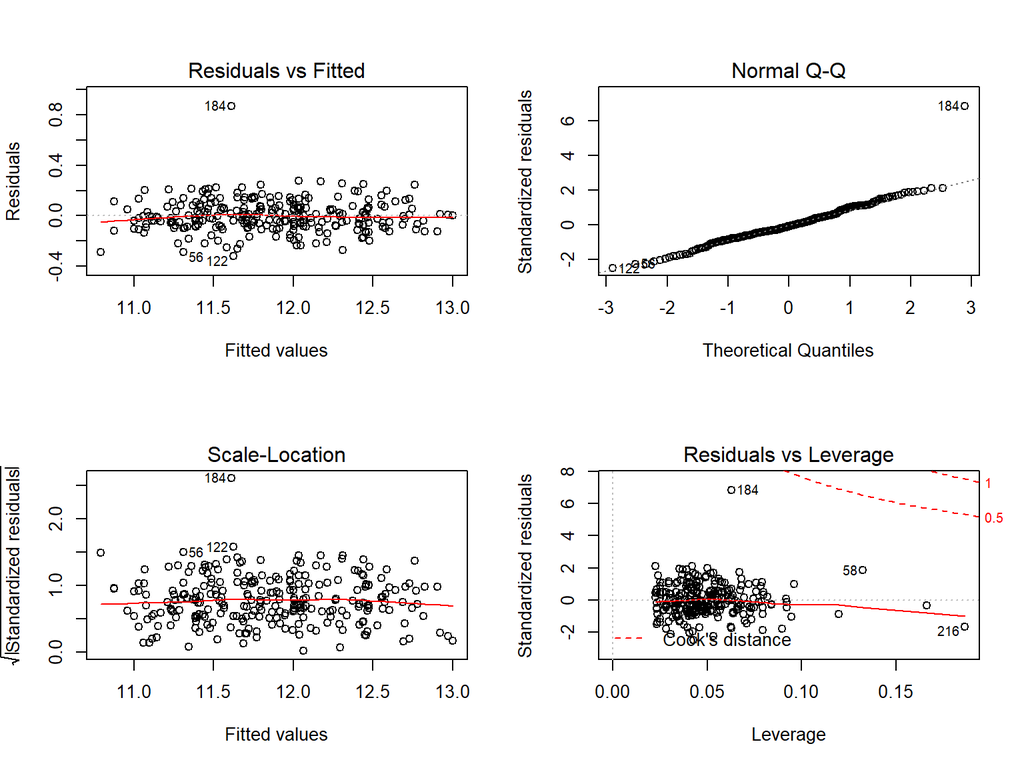

```r
par(mfrow = c(2,2))
plot(reg13)
```

Based on the diagnostic plots for model 1, we can see the constant variance assumptions hold well. The curves in residuals vs fitted plot are horizontal and bounce around 0 which indicates that constant variance is satisfied in our model. Scale-location plot shows the same thing. No.184 observations deviates from the normal line on the qq plot means it might be a outlier. Except from this observation, other observations satisfy normality pretty well.

In addition, the same observation is close to the 0.5 cook’s distance in residuals vs leverage plot, which means No.184 observation might be influential.

For model 2 (interaction gender*rank)

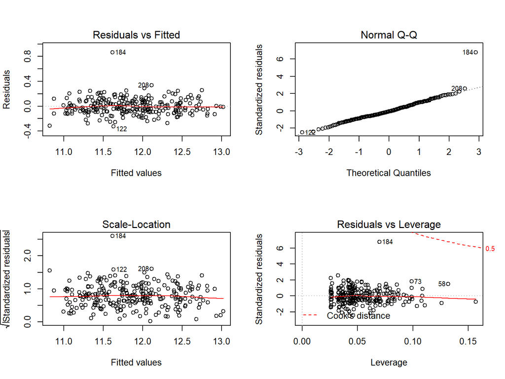

```r
par(mfrow = c(2,2))
plot(reg14)
```

Diagnostic plots for model 2 show similar things, except from No.184 observation, other observations satisfy all of our assumptions very well. It might be influential point in the same time.

## Outlier and influential points

For model 1 (interaction gender*exper)

According to residuals vs fitted plot and scale-location plot, we can find that No.56, No.122, No. 184 observation are outliers. The No.184 obervation are far away from others.

```r
judge = function(x){
  data_o = filter(data, id != x)
  reg13_o = lm(ln_salavg ~ gender*exper + dept + clin + cert + rank, data = data_o)
  sum(abs((reg13_o$coefficients - reg13$coefficients) / reg13$coefficients) > 0.1)
}
judge(56)
```

```
## [1] 0
```

```r
judge(122)
```

```
## [1] 0
```

```r
judge(184)
```

```
## [1] 3
```

```r
data_o = data %>%
  filter(id != 184)

reg13_o = lm(ln_salavg ~ gender*exper + dept + clin + cert + rank, data = data_o)
summary(reg13_o)
```

```
##
## Call:
## lm(formula = ln_salavg ~ gender * exper + dept + clin + cert +
##     rank, data = data_o)
##
## Residuals:
##      Min       1Q   Median       3Q      Max
## -0.32984 -0.07244 -0.01281  0.08040  0.28101
##
## Coefficients:
##                                  Estimate Std. Error t value Pr(>|t|)
## (Intercept)                     10.901154   0.031409 347.067  < 2e-16 ***
## genderMale                       0.098036   0.033558   2.921  0.00381 **
## exper                            0.026579   0.003203   8.298 6.91e-15 ***
## deptPhysiology                  -0.172456   0.025967  -6.641 1.96e-10 ***
## deptGenetics                     0.183945   0.032339   5.688 3.62e-08 ***
## deptPediatrics                   0.199326   0.031994   6.230 2.00e-09 ***
## deptMedicine                     0.519788   0.026450  19.652  < 2e-16 ***
## deptSurgery                      0.922498   0.031583  29.209  < 2e-16 ***
## clinPrimarily clinical emphasis  0.226087   0.019518  11.584  < 2e-16 ***
## certBoard certified              0.199022   0.019052  10.446  < 2e-16 ***
## rankAssociate                    0.131614   0.021413   6.146 3.16e-09 ***
## rankFull                         0.216546   0.023590   9.179  < 2e-16 ***
## genderMale:exper                -0.009676   0.003242  -2.984  0.00313 **
## ---
## Signif. codes:  0 '***' 0.001 '**' 0.01 '*' 0.05 '.' 0.1 ' ' 1
##
## Residual standard error: 0.1184 on 247 degrees of freedom
## Multiple R-squared:  0.9483, Adjusted R-squared:  0.9458
## F-statistic: 377.6 on 12 and 247 DF,  p-value: < 2.2e-16
```

To summary, outliers containning No.56, No.122 and No. 184 observation, only No.184 is influential points in the same time, which means there might be other potential preditor we didn’t take into consideration in our model 1.

```r
influential1 = influence.measures(reg13)$infmat %>%
  as.data.frame() %>%
  dplyr::select(cook.d) %>%
  mutate(case = c(1:261)) %>%
  dplyr::select(case, everything()) %>%
  filter(cook.d > 4 / 261)
```

```r
influential1 %>% knitr::kable()
```

| case | cook.d |
| --- | --- |
| 56 | 0.0220416 |
| 58 | 0.0403659 |
| 59 | 0.0155546 |
| 73 | 0.0170638 |
| 82 | 0.0217901 |
| 122 | 0.0214374 |
| 135 | 0.0243694 |
| 182 | 0.0160004 |
| 184 | 0.2419279 |
| 216 | 0.0484364 |
| 220 | 0.0233413 |

According to cook’s distance of every observation, we found that No. 56, No. 58, No. 59, No. 73, No. 82, No. 122, No. 135, No. 182, No. 184, No. 216, No. 220 are potential influential points (criterion Di > 4/n).

```r
nrow(influential1)
```

```
## [1] 11
```

```r
output = vector(length = 11)

for (i in 1:11) {
  l = influential1[i,1]
  output[i] = judge(l)
}

cbind(case = influential1[,1], output) %>%
  knitr::kable()
```

| case | output |
| --- | --- |
| 56 | 0 |
| 58 | 0 |
| 59 | 0 |
| 73 | 0 |
| 82 | 0 |
| 122 | 0 |
| 135 | 0 |
| 182 | 0 |
| 184 | 3 |
| 216 | 2 |
| 220 | 0 |

Among those potential influential points, only deleting No. 184 or No. 216 cause huge change to coefficient in model1 (criterion>10%). So No. 184 and No. 216 are influential points.

For model 2 (interaction gender*rank)

According to residuals vs fitted plot and scale-location plot, we can find that No. 122, No. 184, No.208 observation are outliers. The No.184 obervation are far away from others.

```r
judge_ = function(x){
  data_o = filter(data, id != x)
  reg14_o = lm(ln_salavg ~ gender*rank + dept + clin + cert + exper, data = data_o)
  sum(abs((reg14_o$coefficients - reg14$coefficients) / reg14$coefficients) > 0.1)
}

judge_(122)
```

```
## [1] 0
```

```r
judge_(184)
```

```
## [1] 4
```

```r
judge_(208)
```

```
## [1] 0
```

After deleting no.184 observation, adjusted R-square improve from 0.9322 to 0.9445. In addition, several coefficient change significantly. Specifically, coefficient of gender changes a lot (0.074 to 0.046). Then we deleted other outliers(No. 122, No. 208) seperately, coefficients of predictor don’t changes a lot.

To summary, outliers containning No.122, No.184 and No. 208 observation. Only No. 184 observation is influential points in the same time, which means there might be other potential preditor we didn’t take into consideration in our model 2.

```r
influential2 = influence.measures(reg14)$infmat %>%
  as.data.frame() %>%
  dplyr::select(cook.d) %>%
  mutate(case = c(1:261)) %>%
  dplyr::select(case, everything()) %>%
  filter(cook.d > 4 / 261)
influential2[,1]
```

```
## [1]  56  58  59  73  82 122 184 208
```

```r
influential2 %>% knitr::kable()
```

| case | cook.d |
| --- | --- |
| 56 | 0.0221121 |
| 58 | 0.0246957 |
| 59 | 0.0157807 |
| 73 | 0.0257712 |
| 82 | 0.0200849 |
| 122 | 0.0201920 |
| 184 | 0.2459881 |
| 208 | 0.0158925 |

```r
nrow(influential2)
```

```
## [1] 8
```

```r
output_ = vector(length = 8)

for (i in 1:8) {
  l = influential2[i,1]
  output_[i] = judge_(l)
}

cbind(case = influential2[,1], output) %>%
  knitr::kable()
```

[output not shown]